# covid-bayesian-test

## Bayesian analysis of COVID-19 antibody tests with unknown specificity and sensitivity

This notebook implements a Bayesian framework first proposed by [Gelman & Carpenter](http://www.stat.columbia.edu/~gelman/research/unpublished/specificity.pdf) to infer the prevalence of COVID-19 based on a Santa Clara County antibody study by [Bendavid *et al.*](https://www.medrxiv.org/content/10.1101/2020.04.14.20062463v2) using PyMC3.

```python
import pymc3 as pm
import numpy as np
import matplotlib.pyplot as plt
import matplotlib as mpl
import pandas as pd
import seaborn as sns


# Set plotting style
sns.set_style('white')
sns.set_context('poster')

%load_ext autoreload
%autoreload 2
%matplotlib inline
%config InlineBackend.figure_format = 'retina'

import warnings
warnings.filterwarnings('ignore')
```

## Data source

The *famous* but (potentially) wrongly analyzed study by Bendavid *et al.* titled [COVID-19 Antibody Seroprevalence in Santa Clara County, California](https://www.medrxiv.org/content/10.1101/2020.04.14.20062463v2)

```python
# Sensitivity (TPR)
sens_tests =  3
sens_vals = [(78, 85),
              (27, 37),
              (25, 35)]

sens_df = pd.DataFrame(sens_vals)
sens_df.columns = ['pos_tests', 'tests']
sens_df['sample_sens'] = sens_df.apply(lambda row: row.pos_tests / row.tests, axis=1)
sens_df
```

|  | pos_tests | tests | sample_sens |
| --- | --- | --- | --- |
| 0 | 78 | 85 | 0.917647 |
| 1 | 27 | 37 | 0.729730 |
| 2 | 25 | 35 | 0.714286 |

```python
# Specificity (TNR)
spec_tests =  13
spec_vals = [(368, 371),
              (30,  30),
              (70,    70),
              (1102, 1102),
              (300,  300),
              (311,  311),
              (500,  500),
              (198,  200),
              (99,   99),
              (29,   31),
              (146,  150),
              (105,  108),
              (50,   52)]

spec_df = pd.DataFrame(spec_vals)
spec_df.columns = ['neg_tests', 'tests']
spec_df['sample_spec'] = spec_df.apply(lambda row: row.neg_tests / row.tests, axis=1)
spec_df

# df.set_index('concentration', inplace=True)
```

|  | neg_tests | tests | sample_spec |
| --- | --- | --- | --- |
| 0 | 368 | 371 | 0.991914 |
| 1 | 30 | 30 | 1.000000 |
| 2 | 70 | 70 | 1.000000 |
| 3 | 1102 | 1102 | 1.000000 |
| 4 | 300 | 300 | 1.000000 |
| 5 | 311 | 311 | 1.000000 |
| 6 | 500 | 500 | 1.000000 |
| 7 | 198 | 200 | 0.990000 |
| 8 | 99 | 99 | 1.000000 |
| 9 | 29 | 31 | 0.935484 |
| 10 | 146 | 150 | 0.973333 |
| 11 | 105 | 108 | 0.972222 |
| 12 | 50 | 52 | 0.961538 |

```python
# Unknown
unk_df = pd.DataFrame([(50, 3330)])
unk_df.columns = ['pos_tests', 'tests']
unk_df['sample_prev'] = unk_df.apply(lambda row: row.pos_tests / row.tests, axis = 1)
unk_df
```

|  | pos_tests | tests | sample_prev |
| --- | --- | --- | --- |
| 0 | 50 | 3330 | 0.015015 |

## Bayesian model

Andrew Gelman and Bob Carpenter proposed a Bayesian inference procedure to estimate [prevalence](https://en.wikipedia.org/wiki/Prevalence) of COVID-19 from several sets of experiements conducted to evaluate the reliability of antibody tests. However, such estimation is hindered by the uncertainties around [sensitivity and specificity](https://en.wikipedia.org/wiki/Sensitivity_and_specificity), as the propogation pf which through a *classical* approach becomes extremly challenging. To circumvent that, one often builds hierarchical models to account for the variations across experiments. The following is a PyMC3 implementation of this procedure.

- **Hierarchical priors:**
  - Let $\gamma_k$ be the **specificity (TNR)** at test site $k$ and $\theta_\gamma^{(k)} = \text{Logit}(\gamma_k) \equiv \log(\gamma_k)-\log (1-\gamma_k)$ be its log-odds. Assume a test specificity log-odds $\mu_\gamma$ and scale of variation $\sigma_\gamma$ such that the $\theta_\gamma$ is distributed as $\theta_\gamma^{(k)} \sim \mathcal{N}(\mu_\gamma, \sigma_\gamma)$. In other words, the specificity $\gamma_k$ follows a [logit-normal distribution](https://en.wikipedia.org/wiki/Logit-normal_distribution): $$\gamma_k \sim \text{LogitNormal}(\mu_\gamma, \sigma_\gamma)$$ Note that we assume that there's no correlation between tests at different sites. Such choice will also pull $\theta_\gamma^{(k)}$ towards $\mu_\gamma$, with $\sigma_\gamma$ controls the *inter-site* variations in specificity. When $\sigma_\gamma \rightarrow 0$, one achieves a *fully-pooled* model where there's no variation across different sites. As $\sigma_\gamma\rightarrow \infty$, one has the *no-pooling* model where the specificity at each site can be estimated independently.
  - Similary, assume that **sensitivity (TPR)** at test site $k$ follows a logit-normal distribution $$\delta_k \sim \text{LogitNormal}(\mu_\delta, \sigma_\delta)$$
  - Prevalence: $\pi\sim U[0,1]$
- **Hyper-priors:**
  - $\mu_\gamma, \mu_\delta \sim$ [Logistic(0,1)](https://en.wikipedia.org/wiki/Logistic_distribution). This parameterization stems from the assumption that Logit$^{-1}(\mu_\gamma)$ (Logit$^{-1}(\mu_\delta)$), the probability of a incorrect (correct) test, follows a uniform distribution in $[0,1]$. More generally, one can show that if $X\in U[0,1]$, $$\mu + \beta \text{ Logit}(X) = \mu + \beta \log \left(\frac{X}{1-X}\right)\sim \text{Logistic }(\mu,\beta).$$
  - $\sigma_\gamma,\sigma_\delta \sim \mathcal{N}_+(0,1)$
- **Likelihoods:**
  - Num. of positive observations: $n_{pos}\sim \text{Binomial}(N_{pos}, \delta)$, where $N_{pos}$ is the num. of subjects in the sensitivity test
  - Num. of negative observations: $n_{neg}\sim \text{Binomial}(N_{neg}, \gamma)$, where $N_{neg}$ is the num. of subjects in the specificity test
  - Num. of positive test results of subjects of unknown status: $$ n_{unk}\sim \text{Binomial}(N_{unk}, \pi\delta + (1-\pi)(1-\gamma)),$$ where $N_{unk}$ is the num. of subjects of unknown status

The posterior is therefore: $$P(\pi| n_{pos}, N_{pos}, n_{neg}, N_{nre}, n_{unk}, N_{unk}, ),$$ which characterizes what we know about the prevalence of the disease, given the observations of sensitity, specificity, and subjects of unknown status.

Note that we can alternatively use a parameterization of the binomial’s chance of success parameter on the log odds scale, where

$$n_{pos}\sim \text{Binomial}(N_{pos}, \text{Logit}^{-1}(\delta)), \qquad n_{neg}\sim \text{Binomial}(N_{neg}, \text{Logit}^{-1}(\gamma))$$

are used. Note also that $\text{Logit}^{-1}(x) = \text{logistic}(x) = 1 / (1+ e^{-x}).$

```python
with pm.Model() as cov19_model:

    # Prior on prevalence
    pi = pm.Uniform('Prevalence', 0, 1)

    # Hyper-priors
    mu_g = pm.Logistic('mu_g', 0, 1)
    mu_d = pm.Logistic('mu_d', 0, 1)
    s_g = pm.HalfNormal('s_g', sigma=1)
    s_d = pm.HalfNormal('s_d', sigma=1)

    # Specificity, TNR
    gamma = pm.LogitNormal('Specificity', mu = mu_g, sigma = s_g)

    # Sensitivity, TPR
    delta = pm.LogitNormal('Sensitivity', mu = mu_d, sigma = s_d)

    # Likelihoods for sensitivity and specificity tests
    # Note that one can alternatively use a parameterization
    # of the binomial’s chance of success parameter on the log odds scale
    # To do so, replace delta by  pm.math.invlogit(delta) and similarly for gamma
    n_pos_lik = pm.Binomial('n_pos', sens_df['tests'], delta, observed = sens_df['pos_tests'])
    n_neg_lik = pm.Binomial('n_neg', spec_df['tests'], gamma, observed = spec_df['neg_tests'])

    # Prob of getting a positive result
    p = pm.Deterministic('p', pi*delta + (1.0 -pi)*(1.0 -gamma))

    # Likelihood of an unknown subject
    n_unk_lik = pm.Binomial('n_unk', unk_df['tests'], p, observed = unk_df['pos_tests'])
```

```python
with cov19_model:
    cov19_trace = pm.sample(10000, step=pm.Metropolis())
```

```
Multiprocess sampling (2 chains in 2 jobs)
CompoundStep
>Metropolis: [Sensitivity]
>Metropolis: [Specificity]
>Metropolis: [s_d]
>Metropolis: [s_g]
>Metropolis: [mu_d]
>Metropolis: [mu_g]
>Metropolis: [Prevalence]
The number of effective samples is smaller than 10% for some parameters.
```

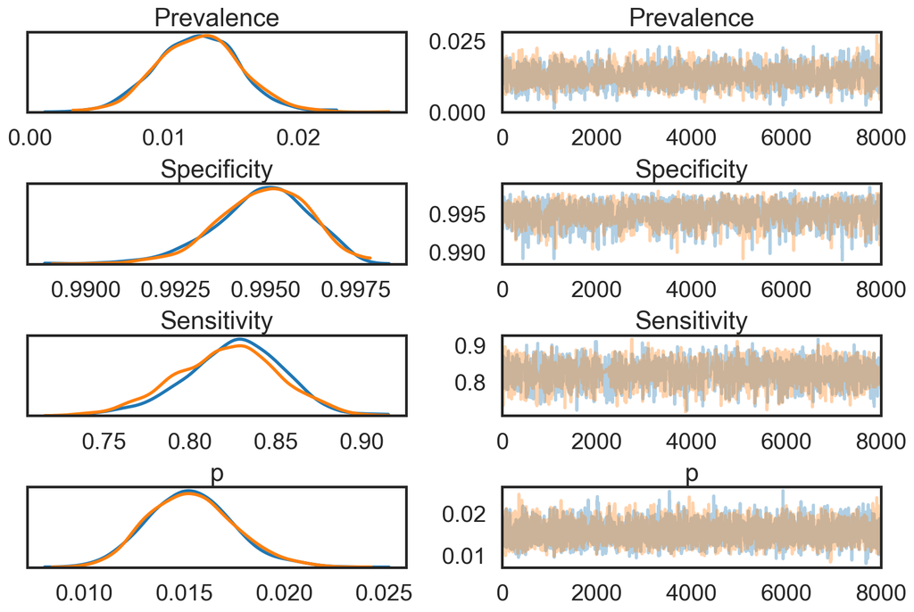

```python
pm.traceplot(cov19_trace[2000:], varnames= ['Prevalence', 'Specificity', 'Sensitivity', 'p'])
plt.show()
```

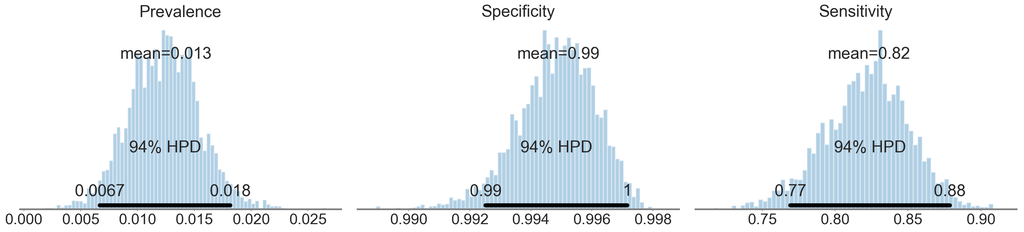

```python
# Get the 94% highest posterior density (Bayesian version of CI)
pm.plot_posterior(cov19_trace[2000:],# color='#87ceeb',
                 varnames= ['Prevalence', 'Specificity', 'Sensitivity'],
                  kind = 'hist')
plt.show()
```

```python
# Print the outcome
pm.summary(cov19_trace).round(3)
```

|  | mean | sd | hpd_3% | hpd_97% | mcse_mean | mcse_sd | ess_mean | ess_sd | ess_bulk | ess_tail | r_hat |
| --- | --- | --- | --- | --- | --- | --- | --- | --- | --- | --- | --- |
| mu_g | 3.952 | 1.620 | 0.647 | 6.296 | 0.064 | 0.045 | 640.0 | 640.0 | 662.0 | 1720.0 | 1.01 |
| mu_d | 1.240 | 0.800 | -0.557 | 2.550 | 0.017 | 0.012 | 2311.0 | 2311.0 | 2334.0 | 3021.0 | 1.00 |
| Prevalence | 0.013 | 0.003 | 0.007 | 0.018 | 0.000 | 0.000 | 1874.0 | 1874.0 | 1861.0 | 2563.0 | 1.00 |
| s_g | 1.154 | 0.754 | 0.001 | 2.427 | 0.029 | 0.021 | 671.0 | 671.0 | 631.0 | 1307.0 | 1.00 |
| s_d | 0.770 | 0.585 | 0.000 | 1.810 | 0.015 | 0.010 | 1614.0 | 1614.0 | 1111.0 | 596.0 | 1.00 |
| Specificity | 0.995 | 0.001 | 0.993 | 0.997 | 0.000 | 0.000 | 1488.0 | 1488.0 | 1454.0 | 1949.0 | 1.00 |
| Sensitivity | 0.823 | 0.029 | 0.769 | 0.879 | 0.001 | 0.000 | 1769.0 | 1762.0 | 1758.0 | 2069.0 | 1.00 |
| p | 0.015 | 0.002 | 0.011 | 0.019 | 0.000 | 0.000 | 3570.0 | 3570.0 | 3547.0 | 4881.0 | 1.00 |